# Open Food Facts - Part I

Date: 08/20/17  
Vishal Bakshi  
vbakshi@ccsf.edu  
Source: https://world.openfoodfacts.org/data

## Objective

Open Food Facts is an open-sourced database of nutritional information for food products across the world. People can add a food product by uploading a picture of the bar code, nutrition facts label, or just the product. The CSV file is ~600MB so Google Sheets could not store it, OpenOffice could but was relatively very slow and pandas quite easily managed the data.

```python
from __future__ import print_function, division
import math
import random
import numpy as np
import pandas as pd
import matplotlib.pyplot as plt
from collections import Counter
```

```python
#In order to see the full URL
pd.set_option('display.max_colwidth',1000)
```

## Importing The CSV

When I first used `read_csv` I received a warning that multiple columns contained multiple data types, so I set `low_memory` to `False`. [Further reading](https://stackoverflow.com/questions/24251219/pandas-read-csv-low-memory-and-dtype-options) on this issue led to some insights about the efficiency (and purpose) of this setting. I would like to test the processing time later on with and without specifying the `dtype` object.

```python
foodfacts = pd.read_csv("openfoodfacts.csv", sep='\t', low_memory=False)
```

Next I replace NaNs in the columns containing country labels, and check with pd.isnull:

```python
df = foodfacts.copy()
country_notnull = df.loc[:, ['countries', 'countries_en', 'countries_tags']].fillna('')
sum((pd.isnull(country_notnull.countries).astype(int))), sum((pd.isnull(country_notnull.countries_en).astype(int))), sum((pd.isnull(country_notnull.countries_tags).astype(int)))
```

```
(0, 0, 0)
```

```python
country_notnull = foodfacts.loc[:, ['countries', 'countries_en', 'countries_tags']].fillna('')
data = foodfacts.copy()
data.loc[:, ['countries', 'countries_en', 'countries_tags']] = country_notnull
sum((pd.isnull(data.countries).astype(int))), sum((pd.isnull(data.countries_en).astype(int))), sum((pd.isnull(data.countries_tags).astype(int)))
```

```
(0, 0, 0)
```

### Validate the Column Names

This data set is also posted by [Kaggle](https://www.kaggle.com/openfoodfacts/world-food-facts) (although I was having trouble extracting the tsv file so I decided to obtain the csv from the organization's website) and the column names are conventiently listed. I want to spot check the `foodfacts` DataFrame column names to make sure the import was successful in that regard.

```python
data.columns
```

```
Index([u'code', u'url', u'creator', u'created_t', u'created_datetime',
       u'last_modified_t', u'last_modified_datetime', u'product_name',
       u'generic_name', u'quantity',
       ...
       u'fruits-vegetables-nuts_100g', u'fruits-vegetables-nuts-estimate_100g',
       u'collagen-meat-protein-ratio_100g', u'cocoa_100g', u'chlorophyl_100g',
       u'carbon-footprint_100g', u'nutrition-score-fr_100g',
       u'nutrition-score-uk_100g', u'glycemic-index_100g',
       u'water-hardness_100g'],
      dtype='object', length=163)
```

### Validate the US Product Count

The current (August 10th) Open Food Facts show a total of 173625 US products, but showed 173626 a couple days ago. I didn't drop any NaN values, so that shouldn't be an issue. I'll spotcheck some of the products and match them with their URL since I only have 169434 products categorized with one of the three country labels: `countries` (`US`), `countries_tags` (`en:united-states`), and `countries_tags` (`United States`).

```python
urls = 'http://world-en.openfoodfacts.org/product/' + data.loc[:,'code']
data['urls'] = urls
```

```python
usfoods = data[data['countries'].str.contains("US") | data['countries_tags'].str.contains("united-states") | data['countries_en'].str.contains("United States")]
len(usfoods)
```

```
169434
```

```python
usfoods.loc[150000,['code', 'urls', 'product_name', 'brands', 'serving_size', 'saturated-fat_100g', 'iron_100g']]
```

```
code                                                            0810511010647
urls                  http://world-en.openfoodfacts.org/product/0810511010647
product_name            Orchards, Montmorency Cherries Dipped In Greek Yogurt
brands                                       Stoneridge,  Stoneridge Orchards
serving_size                                                  40 g (0.25 cup)
saturated-fat_100g                                                       12.5
iron_100g                                                                   0
Name: 150000, dtype: object
```

So far so good, although I'll be wary of checking the consistency of the food entries, and spend some time looking for better, more accurate methods of data validation besides my rather arbitrary spot checks. Next, I'll start exploring the disributions the different nutrition content.

## Visualizing the Nutrition Distributions

I'm going to start off by creating CDFs for fat, sugar, protein and sodium content of the US foods. The maximum possible value for each item (fat, sugar, protein and sodium) is 100g per 100g and the minimum possible value for each item is 0g per 100g. I'll query this range before plotting the distributions:

```python
us_fat = usfoods.query('fat_100g >= 0 & fat_100g <= 100').dropna(subset=['fat_100g']).fat_100g
us_sugar = usfoods.query('sugars_100g >= 0 & sugars_100g <= 100').dropna(subset=['sugars_100g']).sugars_100g
us_protein = usfoods.query('proteins_100g >= 0 & proteins_100g <= 100').dropna(subset=['proteins_100g']).proteins_100g
us_sodium = usfoods.query('sodium_100g >= 0 & sodium_100g <= 100').dropna(subset=['sodium_100g']).sodium_100g
```

```python
us_fat = np.sort(np.asarray(us_fat))
us_sugar = np.sort(np.asarray(us_sugar))
us_protein = np.sort(np.asarray(us_protein))
us_sodium = np.sort(np.asarray(us_sodium))
```

```python
us_fat_cdf = np.cumsum(us_fat/np.sum(us_fat))
us_sugar_cdf = np.cumsum(us_sugar/np.sum(us_sugar))
us_protein_cdf = np.cumsum(us_protein/np.sum(us_protein))
us_sodium_cdf = np.cumsum(us_sodium/np.sum(us_sodium))
```

```python
def PlotCdfs(xs, ys, ax, title):
    ax.plot(xs, ys)
    ax.set_title(title, fontsize=16)
    #ax.grid(color='#d9d9d9', axis='x')
    ax.set_xlabel(title, fontsize=12)
    ax.set_ylabel('CDF', fontsize=12)
```

```python
def PlotVertLine(xarr, cdf, ax):
    index = np.where(cdf>0.99)
    x99 = xarr[index[0][0]]
    ax.plot([x99, x99], [0, 1])
    ax.text(120, 0.5, '99th %-ile: ' + str(x99) + 'g')
```

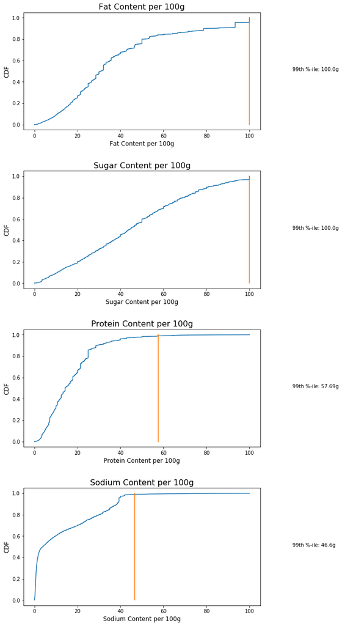

```python
titles = ['Fat Content per 100g', 'Sugar Content per 100g', 'Protein Content per 100g', 'Sodium Content per 100g']
xarrs = [us_fat, us_sugar, us_protein, us_sodium]
yarrs = [us_fat_cdf, us_sugar_cdf, us_protein_cdf, us_sodium_cdf]

fig, ax = plt.subplots(nrows=4, ncols=1, figsize=(8, 18))

for i, xarr in enumerate(xarrs):
    PlotCdfs(xarr, yarrs[i], ax[i], titles[i])
    PlotVertLine(xarr, yarrs[i], ax[i])

plt.tight_layout(pad=3)
plt.show()
```

Using these 99th %-ile values, I'll plot the histograms for each item:

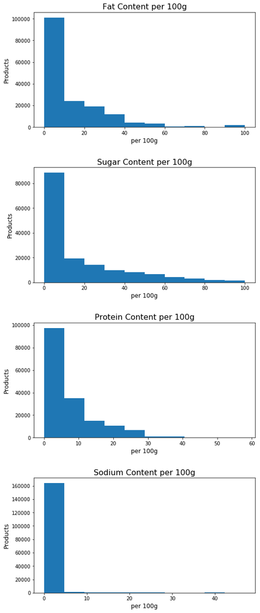

```python
fig, ax = plt.subplots(nrows=4, ncols=1, figsize=(8,18))
ranges = [(0, 100), (0, 100), (0, 58), (0, 47)]
for i, xarr in enumerate(xarrs):
    ax[i].hist(xarr, bins=10, range=ranges[i])
    ax[i].set_xlabel('per 100g', fontsize=12)
    ax[i].set_ylabel('Products', fontsize=12)
    ax[i].set_title(titles[i], fontsize=16)

plt.tight_layout(pad=3)
plt.show()
```

## Next Steps:

The plots in this exercise help to show how much nutrition content (fat, sugar, protein and sodium) the majority of the products contain. In the next exercise I post related to this analysis, I'll import this data into R and analyze the relationships between different variables (nutrition content items) and comment on any trends that are apparent and also significant.